# Homework_4

Marjan Rezvani

10/13/2020

#### we are going to do some regression models to analyze the impact of each variable on wages.

```r
load('/Users/marjanrezvani/Documents/Fall2020/eco_stat/data/acs2017_ny/acs2017_ny_data.RData')
attach(acs2017_ny)
use_varb <- (AGE >= 25) & (AGE <= 55) & (LABFORCE == 2) & (WKSWORK2 > 4) & (UHRSWORK >= 35)
dat_use <- subset(acs2017_ny,use_varb)
detach()
attach(dat_use)

#summary(dat_use)

my_model1 <- lm(INCWAGE ~ AGE + female + AfAm + RENT + Amindian + race_oth + CITIZEN + educ_hs + educ_somecoll + educ_college + educ_advdeg)
summary(my_model1)
```

```
##
## Call:
## lm(formula = INCWAGE ~ AGE + female + AfAm + RENT + Amindian +
##     race_oth + CITIZEN + educ_hs + educ_somecoll + educ_college +
##     educ_advdeg)
##
## Residuals:
##     Min      1Q  Median      3Q     Max
## -152534  -33176  -10656   13098  625668
##
## Coefficients:
##                 Estimate Std. Error t value Pr(>|t|)
## (Intercept)   -12395.399   2494.556  -4.969 6.75e-07 ***
## AGE             1388.763     40.904  33.952  < 2e-16 ***
## female        -25040.882    720.341 -34.763  < 2e-16 ***
## AfAm          -12258.940   1145.587 -10.701  < 2e-16 ***
## RENT               2.748      0.436   6.302 2.96e-10 ***
## Amindian      -10230.599   6065.576  -1.687   0.0917 .
## race_oth       -9030.847   1138.224  -7.934 2.17e-15 ***
## CITIZEN         -538.688    369.818  -1.457   0.1452
## educ_hs        11607.831   1817.680   6.386 1.72e-10 ***
## educ_somecoll  23692.786   1866.664  12.693  < 2e-16 ***
## educ_college   58118.403   1826.283  31.823  < 2e-16 ***
## educ_advdeg    83888.008   1863.843  45.008  < 2e-16 ***
## ---
## Signif. codes:  0 '***' 0.001 '**' 0.01 '*' 0.05 '.' 0.1 ' ' 1
##
## Residual standard error: 76740 on 46959 degrees of freedom
## Multiple R-squared:  0.1505, Adjusted R-squared:  0.1503
## F-statistic: 756.2 on 11 and 46959 DF,  p-value: < 2.2e-16
```

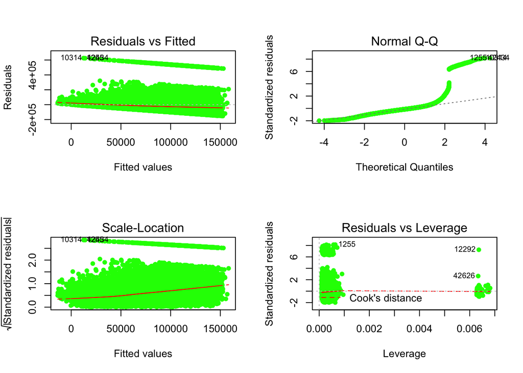

```r
par(mfrow=c(2,2))
plot(my_model1,col="green",pch=16,cex=1,lwd=1,lty=2)
```

#### In first try, I choose different variables for my model such as RENT, CITIZEN, and remove Asian and hispanic.

#### As you can see in the Diagnostic plots, there is not a good model. I am going to explain each plot.

#### 1. Residuals versus predicted values(Fitted) plot:

#### It indicates a kind of nonsymetric pattern, which means the linearity assumption is violated.

#### 2. Normal Q_Q plot:

#### It is used to examine whether the residuals are normally distributed. so it’s good if residuals points follow the straight

#### dashed line. but as we can see in my plot, residuals points do not follow the straight dashed line.

#### 3. Scale-Location plot:(or Spread-Location)

#### Horizontal line with equally spread points is a good indication of homoscedasticity. this is not the case in our example, where we have a heteroscedasticity problem.

#### 4. Residuals vs Leverage plot:

#### This plot is used to identify influential cases, that is extreme values that might influence the regression results when included or excluded from the analysis. area of intent is upper right and bottom right of plot. we can see two values in these areas which should not be excluded.

```r
require(stargazer)
stargazer(my_model1, type = "text")
```

```
##
## ===============================================
##                         Dependent variable:
##                     ---------------------------
##                               INCWAGE
## -----------------------------------------------
## AGE                        1,388.763***
##                              (40.903)
##
## female                    -25,040.880***
##                              (720.341)
##
## AfAm                      -12,258.940***
##                             (1,145.587)
##
## RENT                         2.748***
##                               (0.436)
##
## Amindian                   -10,230.600*
##                             (6,065.576)
##
## race_oth                   -9,030.847***
##                             (1,138.224)
##
## CITIZEN                      -538.688
##                              (369.818)
##
## educ_hs                    11,607.830***
##                             (1,817.680)
##
## educ_somecoll              23,692.790***
##                             (1,866.664)
##
## educ_college               58,118.400***
##                             (1,826.283)
##
## educ_advdeg                83,888.010***
##                             (1,863.843)
##
## Constant                  -12,395.400***
##                             (2,494.556)
##
## -----------------------------------------------
## Observations                  46,971
## R2                             0.150
## Adjusted R2                    0.150
## Residual Std. Error   76,735.850 (df = 46959)
## F Statistic         756.187*** (df = 11; 46959)
## ===============================================
## Note:               *p<0.1; **p<0.05; ***p<0.01
```

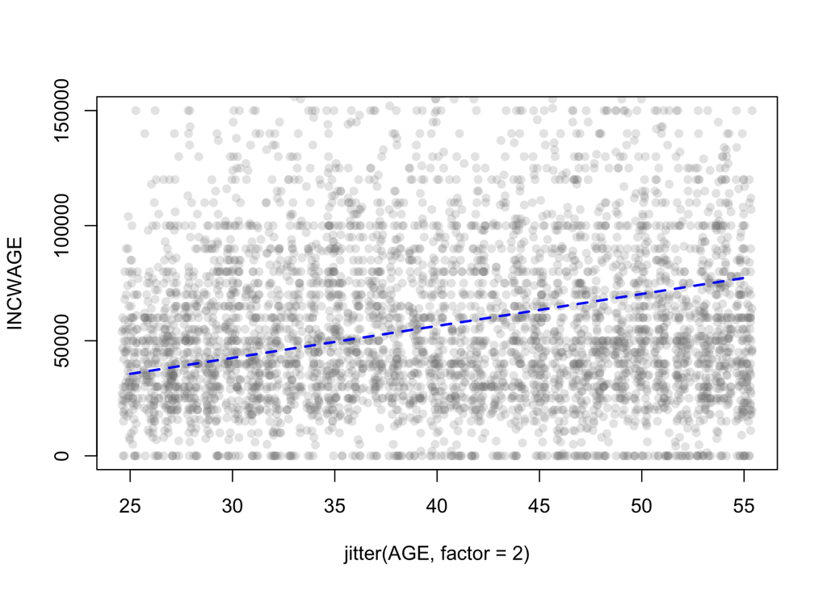

```r
NNobs <- length(INCWAGE)
set.seed(11111)
graph_obs <- (runif(NNobs) < 0.1)
dat_graph <-subset(dat_use,graph_obs)

plot(INCWAGE ~ jitter(AGE, factor = 2), pch = 16, col = rgb(0.5, 0.5, 0.5, alpha = 0.2), ylim = c(0,150000), data = dat_graph)


to_be_predicted2 <- data.frame(AGE = 25:55, female = 1, AfAm = 0, RENT=0, Amindian = 1, race_oth = 1, CITIZEN = 1, educ_hs = 0, educ_somecoll = 0, educ_college = 1, educ_advdeg = 0)
to_be_predicted2$yhat <- predict(my_model1, newdata = to_be_predicted2)

lines(yhat ~ AGE, data = to_be_predicted2, col="blue",cex=2,lwd=2,lty=2)
```

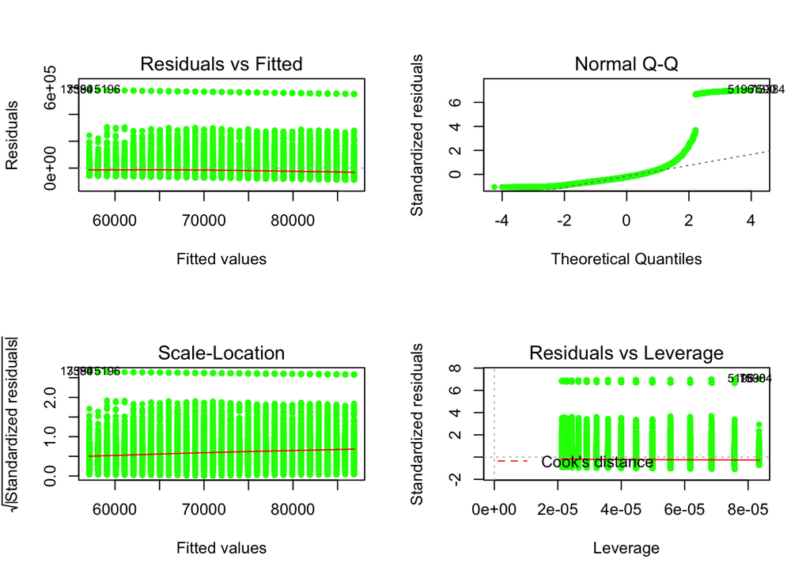

```r
age_n<-as.numeric(as.character(dat_use$INCWAGE))
par(mfrow=c(2,2))
Wage_of_age<-lm(INCWAGE~AGE)
plot(Wage_of_age,col="green",pch=20,cex=1,lwd=1,lty=1)
```

```r
summary(Wage_of_age)
```

```
##
## Call:
## lm(formula = INCWAGE ~ AGE)
##
## Residuals:
##    Min     1Q Median     3Q    Max
## -86853 -38985 -18021  12041 580882
##
## Coefficients:
##             Estimate Std. Error t value Pr(>|t|)
## (Intercept)  32338.6     1747.3   18.51   <2e-16 ***
## AGE            991.2       42.1   23.54   <2e-16 ***
## ---
## Signif. codes:  0 '***' 0.001 '**' 0.01 '*' 0.05 '.' 0.1 ' ' 1
##
## Residual standard error: 82760 on 46969 degrees of freedom
## Multiple R-squared:  0.01166,    Adjusted R-squared:  0.01164
## F-statistic: 554.2 on 1 and 46969 DF,  p-value: < 2.2e-16
```

#### As it is obviousin the plots, age has positively correlated with income wage. the income increases with the increase of age in the range of our selective age.

#### for the other one, I am going to consider educ_advdeg which it surely has a direct relation with the income.

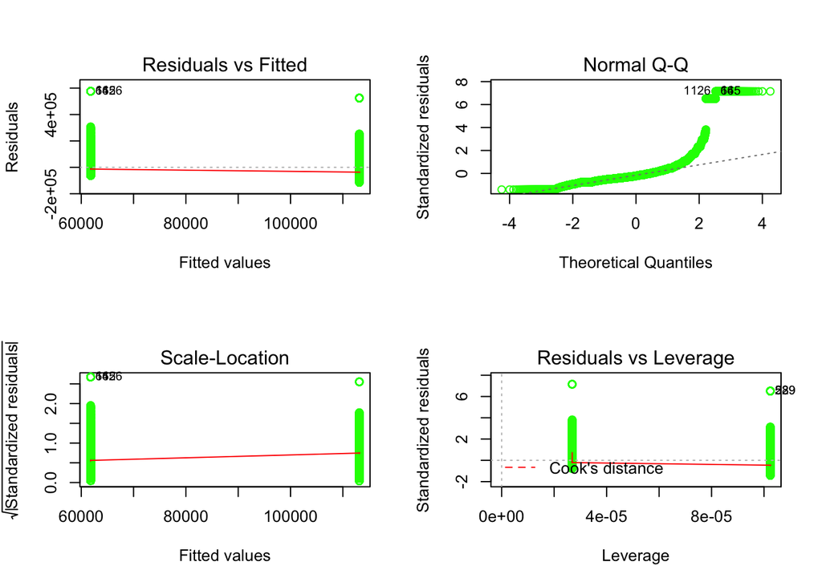

```r
my_model2 <- lm(INCWAGE ~educ_advdeg, data = dat_use)
par(mfrow=c(2,2))
plot(my_model2,col="green")
```

####or for the other one we have:

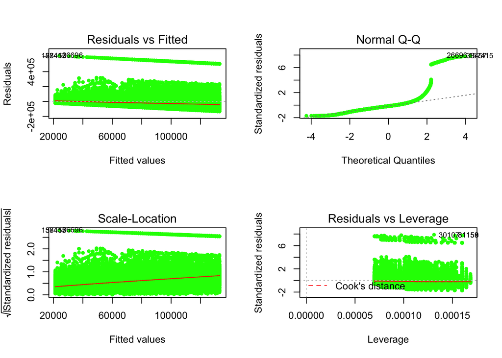

```r
my_model3<-lm(INCWAGE ~AGE + educ_somecoll + educ_college + educ_advdeg,data = dat_use)
par(mfrow=c(2,2))
plot(my_model3,col="green",pch=20,cex=1,lwd=1,lty=1)
```

```r
require(stargazer)
stargazer(my_model3, type = "text")
```

```
##
## ================================================
##                         Dependent variable:
##                     ----------------------------
##                               INCWAGE
## ------------------------------------------------
## AGE                         1,338.311***
##                               (40.166)
##
## educ_somecoll              11,922.220***
##                             (1,021.629)
##
## educ_college               47,168.940***
##                              (955.691)
##
## educ_advdeg                71,413.330***
##                             (1,026.291)
##
## Constant                   -12,161.040***
##                             (1,815.681)
##
## ------------------------------------------------
## Observations                   46,971
## R2                             0.123
## Adjusted R2                    0.123
## Residual Std. Error   77,964.610 (df = 46966)
## F Statistic         1,645.599*** (df = 4; 46966)
## ================================================
## Note:                *p<0.1; **p<0.05; ***p<0.01
```